# Data Exploration of Grupo Bimbo Data Set

Keith Hultman

June 13, 2016

# Load Data

```r
setwd("/Volumes/Half_Dome/datasets/grupo-bimbo/")
load("train1.Rdata")
load("train2.Rdata")
load("validate.Rdata")
load("test.Rdata")
load("clients.Rdata")
load("products.Rdata")
load("town_state.Rdata")
```

# Products missing in the train set that are in the Kaggle test set

The kaggle page mentioned that there will be products in the test set that were not in the train set.

```r
train1_products <- unique(train1$product)
test_products <- unique(test$product)

# Number of train products missing from test products
nrow(train1_products[!(train1_products %in% test_products)])
```

```r
# Test products missing from train products
new_products <- as.data.frame(test_products[!(test_products %in% train1_products)])
colnames(new_products) <- c("product")

new_products <- new_products %>%
  left_join(products, by = "product")

# Number of products in test set missing in full training set:
nrow(new_products)
```

```
## [1] 34
```

# What about for our split data? Are there any products missing in train2 that are in the validate test set?

We are splitting the training set into a smaller training set and a validation set that we will use to train our models.

```r
validate_products <- unique(validate$product)
train2_products <- unique(train2$product)


# Train2 products missing from validate products
# These products will have models, but will not be predicted with the validation data set
nrow(train2_products[!(train2_products %in% validate_products)])
```

```r
# Validate products missing from train2 products
# These products will not have a trained model prediction!
new_validate_products <- as.data.frame(validate_products[!(validate_products %in% train2_products)])
colnames(new_validate_products) <- c("product")

new_validate_products <- new_validate_products %>%
  left_join(products, by = "product")

# new_validate_products

# Number of products in our validate test set that are not in our train2 data. We will need to have a naive model for new products.
nrow(new_validate_products)
```

```
## [1] 62
```

This is good. We will be able to test how our model works for new products that are not in the training set. We will need to have some kind of naive model prediction for new products.

# From now on, only look at our split training data: the train2 data set

## Summarize Data

### Data tables and columns

These are the tables we have to work with.

```
## [1] "Training set"
```

```
## Source: local data frame [53,364,883 x 11]
##
##     week depot channel route client product sales_units sales
##    <int> <int>   <int> <int>  <int>   <int>       <int> <dbl>
## 1      3  1110       7  3301  15766    1212           3 25.14
## 2      3  1110       7  3301  15766    1216           4 33.52
## 3      3  1110       7  3301  15766    1238           4 39.32
## 4      3  1110       7  3301  15766    1240           4 33.52
## 5      3  1110       7  3301  15766    1242           3 22.92
## 6      3  1110       7  3301  15766    1250           5 38.20
## 7      3  1110       7  3301  15766    1309           3 20.28
## 8      3  1110       7  3301  15766    3894           6 56.10
## 9      3  1110       7  3301  15766    4085           4 24.60
## 10     3  1110       7  3301  15766    5310           6 31.68
## ..   ...   ...     ...   ...    ...     ...         ...   ...
## Variables not shown: returns_units <int>, returns <dbl>, demand <int>.
```

```
## [1] "Validation set"
```

```
## Source: local data frame [20,815,581 x 11]
##
##     week depot channel route client product sales_units  sales
##    <int> <int>   <int> <int>  <int>   <int>       <int>  <dbl>
## 1      8  1110       7  3301  15766    1212           4  33.52
## 2      8  1110       7  3301  15766    1216           5  41.90
## 3      8  1110       7  3301  15766    1220           1   7.64
## 4      8  1110       7  3301  15766    1238           3  29.49
## 5      8  1110       7  3301  15766    1240           2  16.76
## 6      8  1110       7  3301  15766    1242           1   7.64
## 7      8  1110       7  3301  15766    1250           8  61.12
## 8      8  1110       7  3301  15766    1309           3  20.28
## 9      8  1110       7  3301  15766    3894           2  18.70
## 10     8  1110       7  3301  15766   30531          17 132.26
## ..   ...   ...     ...   ...    ...     ...         ...    ...
## Variables not shown: returns_units <int>, returns <dbl>, demand <int>.
```

```
## [1] "Client file"
```

```
## Source: local data frame [935,362 x 2]
##
##    client                             client_name
##     <int>                                  <fctr>
## 1       0                              SIN NOMBRE
## 2       1                        OXXO XINANTECATL
## 3       2                              SIN NOMBRE
## 4       3                               EL MORENO
## 5       4 SDN SER  DE ALIM  CUERPO SA CIA  DE INT
## 6       4    SDN SER DE ALIM CUERPO SA CIA DE INT
## 7       5                              LA VAQUITA
## 8       6                                  LUPITA
## 9       7                            I M EL GUERO
## 10      8                    MINI SUPER LOS LUPES
## ..    ...                                     ...
```

```
## [1] "Product file"
```

```
## Source: local data frame [2,592 x 2]
##
##    product                           product_name
##      <int>                                 <fctr>
## 1        0                      NO IDENTIFICADO 0
## 2        9              Capuccino Moka 750g NES 9
## 3       41 Bimbollos Ext sAjonjoli 6p 480g BIM 41
## 4       53         Burritos Sincro 170g CU LON 53
## 5       72    Div Tira Mini Doradita 4p 45g TR 72
## 6       73      Pan Multigrano Linaza 540g BIM 73
## 7       98           Tostado Integral 180g WON 98
## 8       99                 Pan Blanco 567g WON 99
## 9      100 Super Pan Bco Ajonjoli 680g SP WON 100
## 10     106     Wonder 100pct mediano 475g WON 106
## ..     ...                                    ...
```

```
## [1] "Location file"
```

```
## Source: local data frame [790 x 3]
##
##    depot                    town            state
##    <int>                  <fctr>           <fctr>
## 1   1110      2008 AG. LAGO FILT     MÉXICO, D.F.
## 2   1111   2002 AG. AZCAPOTZALCO     MÉXICO, D.F.
## 3   1112     2004 AG. CUAUTITLAN ESTADO DE MÉXICO
## 4   1113      2008 AG. LAGO FILT     MÉXICO, D.F.
## 5   1114    2029 AG.IZTAPALAPA 2     MÉXICO, D.F.
## 6   1116    2011 AG. SAN ANTONIO     MÉXICO, D.F.
## 7   1117       2001 AG. ATIZAPAN ESTADO DE MÉXICO
## 8   1118       2007 AG. LA VILLA     MÉXICO, D.F.
## 9   1119 2013 AG. MEGA NAUCALPAN ESTADO DE MÉXICO
## 10  1120   2018 AG. TEPALCATES 2     MÉXICO, D.F.
## ..   ...                     ...              ...
```

### Overview of timeframe and sample sizes

```r
# Weeks in training data set and number of samples per week
train2 %>%
  group_by(week) %>%
  summarise(Number = n())
```

```
## Source: local data frame [5 x 2]
##
##    week   Number
##   <int>    <int>
## 1     3 11165207
## 2     4 11009593
## 3     5 10615397
## 4     6 10191837
## 5     7 10382849
```

```r
# Weeks and samples in the validate set
validate %>%
  group_by(week) %>%
  summarise(Number = n())
```

```
## Source: local data frame [2 x 2]
##
##    week   Number
##   <int>    <int>
## 1     8 10406868
## 2     9 10408713
```

```r
# Unique variables in train2 dataset
train2 %>% summarise(Depots = n_distinct(depot), Channels = n_distinct(channel), Routes = n_distinct(route), Clients = n_distinct(client), Products = n_distinct(product))
```

```
## Source: local data frame [1 x 5]
##
##   Depots Channels Routes Clients Products
##    <int>    <int>  <int>   <int>    <int>
## 1    552        9   3495  862267     1737
```

### Let’s look at trends of random products across all clients.

I was wondering if there were some patterns of demand that crossed all stores.

```r
set.seed(65)
product_sample <- products %>% sample_n(15)
# product_sample

# Scatterplot of sample products
# train2 %>%
#   filter(product %in% product_sample$product) %>%
#   ggplot(aes(x = week, y = demand)) +
#   geom_point() +
#   facet_wrap(~ product, scale = "free_y")

# Trend lines of average demand over time for sample products
product_trend_sample <- train2 %>%
  filter(product %in% product_sample$product) %>%
  group_by(product, week) %>%
  summarise(ave_demand = mean(demand))

product_trend_sample  %>% summarise(n_distinct(product))
```

```
## Source: local data frame [12 x 2]
##
##    product n_distinct(product)
##      <int>               <int>
## 1     1240                   1
## 2     5355                   1
## 3     5710                   1
## 4    30415                   1
## 5    31669                   1
## 6    32863                   1
## 7    35455                   1
## 8    36309                   1
## 9    36994                   1
## 10   43059                   1
## 11   44829                   1
## 12   46104                   1
```

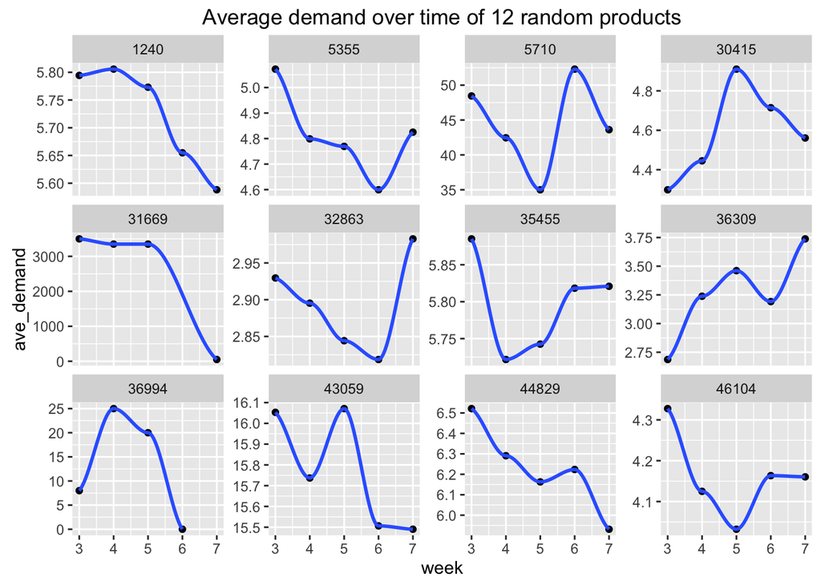

```r
# Of the 15 random products, 12 products have demand in this training set

ggplot(product_trend_sample, aes(x = week, y = ave_demand)) +
  geom_point() +
  stat_smooth() +
  facet_wrap(~ product, scale = "free_y") +
  ggtitle("Average demand over time of 12 random products")
```

Let’s look at demand for only one of those 12 products, product 5710

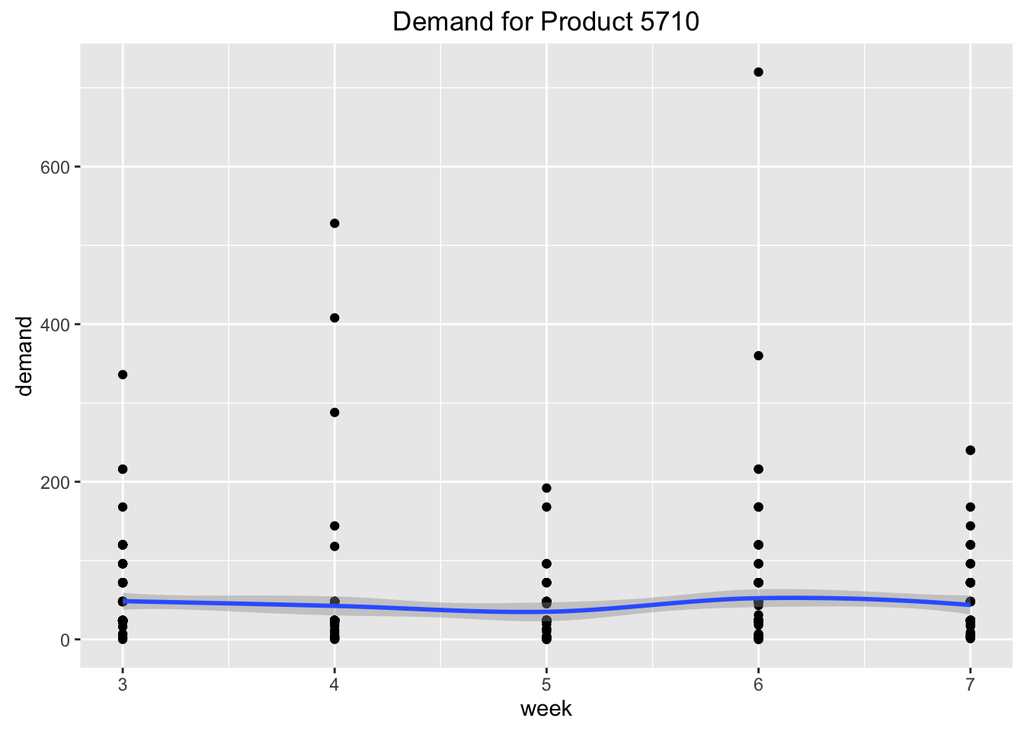

```r
# Looking at the trend of one of those products, 5710
product5710 <- train2 %>%
  filter(product == 5710)

ggplot(product5710, aes(x = week, y = demand)) +
  geom_point() +
  stat_smooth() +
  ggtitle("Demand for Product 5710")
```

And a few random individual stores for this product:

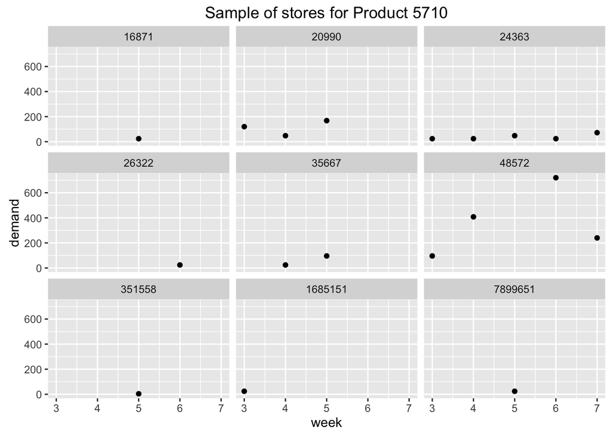

```r
store_sample <- sample_n(as.data.frame(unique(product5710$client)), 9)
colnames(store_sample) <- "clientsample"

product5710_store_sample <- product5710 %>%
  filter(client %in% store_sample$clientsample)

ggplot(product5710_store_sample, aes(x = week, y = demand)) +
  geom_point() +
  facet_wrap(~client) +
  ggtitle("Sample of stores for Product 5710")
```